**Machine Learning for Mechanical Engineering**  
**Homework 08 - Solution**

Instructor: Prof. Seungchul Lee  
http://iai.postech.ac.kr/  
Industrial AI Lab at POSTECH

# Problem 5

1) What is the relationship between PCA and SVD?

2) Derive Fisher discriminant analysis from scratch.

3) Explain how SVD can do low rank approximation.

# Solution 5

1)

Any real symmetric and positive definite matrix $B$ has a eigen decompositon

$$B=S\Sigma S^T$$

A real matrix $A_{(m\times n)}$ , where $m > n$ , has the decomposition $$A=U \Sigma V^T$$

From $A$ (skinny and full rank) we can construct positive-definite symmetric matrices, $ATA$

$$A^{T}A=V^{T}U^{T}U \Sigma V^{T}=V \Sigma^{T} \Sigma V^{T}$$

PCA by SVD

$$B=A^{T}A=V \Sigma^{T} \Sigma V^{T}=VΛV^{T}$$

Note tha in PCA,

$$VSV^{T}(where S=\frac{1}{m}X^{T}X=(\frac{X}{\sqrt(m)})^{T}\frac{X}{\sqrt{m}}=A^{T}A)$$

2)

sample mean $\mu=\sum_{x_{(i)}\in C}^{n} x_{i}$ , sample variance $\frac{1}{n-1}\sum_{x_{(i)}\in C}^{n} (x_{i}-\mu )(x_{i}-\mu )^{T}$ projected mean $E[\hat{y}\mid x \in C] = \mu ^{T}w$ , projected variance $var[\hat{y}\mid x \in C] = \omega ^{T}S\omega$ for 2 classes,

$$\underset{\omega}{\max} \frac{\text{seperation of projected means }}{\text{sum of within class variances}} \implies \underset{\omega}{\max} \frac{(\mu_{0}^{T}\omega-\mu_{1}^{T}\omega)^{2}}{n_{0}\omega^{T}S_{0}\omega+n_{1}\omega^{T}S_{1}\omega} $$

$$J(\omega)= \frac{((\mu_{0}^{T}-\mu_{1}^{T})\omega)^{2}}{\omega^{T}(n_{0}S_{0}+n_{1}S_{1})\omega} = \frac{(m^{T}\omega)}{\omega^{T}\sum\omega} $$

$$m=\mu^{T}_{0}−\mu^{T}_{1}$$$$\sum=n_{0}S_{0}+n_{1}S_{1}=R^{T}R$$$$u=Rω\Rightarrow\omega=R^{-1}u$$$$J(u)=\frac{(m^{T}R{−1}u)^{2}}{\omega^{T}R^{T}R\omega}=\frac{((R^{−T}m)^{T}\frac{u}{\left\|u \right\|})}{u^{T}u}=((R^{-T}m)^{T}\frac{u}{∥u∥})^{2} $$$$J(u)=((R^{−T}m)^{T}\frac{u}{∥u∥})^{2} \;\; \text{is maximum, when} \; u=aR^{−T}m$$$$u=aR^{−T}m=aR^{−T}(\mu_{0}−\mu_{1})$$$$\omega=R^{−1}u=aR^{−1}R^{-T}(\mu_{0}−\mu_{1})=a(R^{T}R)^{−1}(\mu_{0}-\mu_{1})=a\sum^{−1}(\mu_{0}−\mu_{1})$$$$\omega=a(n_{0}S_{0}+n_{1}S_{1})^{−1}(\mu_{0}−\mu_{1})$$

3)

by SVD,

$$A=UΣ V^{T}$$

In order to compress $A$ without losing too much information of $A$ , we can consider that the large singular values ($\sigma$) has large information of $A$ because the singular value ($\sigma_i$) is the scaling factor corresponding to unit vector $u_i$

$A=UΣ V^{T}$can be approximated about the large singular values, it is a low rank approximation as the dimension reduction

$$A=U_{r}Σ_{r} V_{r}^{T} = \sum_{i=1}^{r}\sigma_{i}u_{i}v_{i}^{T} (r\leq n) $$

# Problem 11

Consider the following matrix:

$$ \begin{align*} A = \begin{bmatrix} -1 & 1 & 0 \\ 0 & -1 & 1 \\ \end{bmatrix} \end{align*} $$

(a) Compute the Singular Value Decomposition (SVD) of matrix $A$ using python.

```python
## your code here
#
```

(b) In this time, solve it with your own hand (i.e, Do SVD by hands).

(c) Compute the rank 1 approximation of matrix $A$ by hands.

# Solution 11

Consider the following matrix:

$$ \begin{align*} A = \begin{bmatrix} -1 & 1 & 0 \\ 0 & -1 & 1 \\ \end{bmatrix} \end{align*} $$

(a) Compute the Singular Value Decomposition (SVD) of matrix $A$ using python.

```python
import numpy as np
A = np.array([[-1, 1, 0],
              [0, -1, 1]])

[U, S, VT] = np.linalg.svd(A, full_matrices = True)

U = np.asmatrix(U)
S = np.asmatrix(np.diag(S))
VT = np.asmatrix(VT)

print(U.shape, S.shape, VT.shape, '\n')
print(U, '\n')
print(S, '\n')
print(VT)
```

```
(2, 2) (2, 2) (3, 3)

[[-0.70710678  0.70710678]
 [ 0.70710678  0.70710678]]

[[1.73205081 0.        ]
 [0.         1.        ]]

[[ 4.08248290e-01 -8.16496581e-01  4.08248290e-01]
 [-7.07106781e-01 -2.78976253e-16  7.07106781e-01]
 [ 5.77350269e-01  5.77350269e-01  5.77350269e-01]]
```

(b) In this time, solve it with your own hand (i.e, Do SVD by hands).

$$\begin{align*} det \left(A^TA - \lambda I \right) &= \begin{bmatrix}\ 1 - \lambda & -1 & 0 \\ -1 & 2 - \lambda & -1 \\ 0 & -1 & 1 - \lambda \\ \end{bmatrix} \\ & = (1 - \lambda)^2(2 - \lambda) - (1 - \lambda) - (1 - \lambda) \\ & = (1 - \lambda)\left((1 - \lambda)(2 - \lambda) - 2 \right) \\ & = (1 - \lambda)\lambda(\lambda - 3) = 0 \end{align*}$$

Thus, we have $\lambda = 3, 1, 0.$ Therefore, the singular values are: $\sqrt{3}, 1, 0.$

To determine V, we solve the eigenvalue-eigenvector problems. For $\lambda = 3:$

$$\begin{align*} \begin{bmatrix}\ -2 & -1 & 0 \\ -1 & -1 & -1 \\ 0 & -1 & -2 \\ \end{bmatrix} = \begin{bmatrix} x \\ y \\ z \\ \end{bmatrix} = \begin{bmatrix} -2x -y \\ -x -y -z \\ -y -2z \\ \end{bmatrix} = \begin{bmatrix} 0 \\ 0 \\ 0 \\ \end{bmatrix} \end{align*}$$

Thus we can set $\begin{bmatrix} x & y & z \end{bmatrix} = \begin{bmatrix} 1 & -2 & 1 \end{bmatrix}^T,$ but we need to normalize it to have a unit length.  
Thus we have $v_1 = \sqrt{6}^{-1}\begin{bmatrix} 1 & -2 & 1 \end{bmatrix}^T.$  
For $\lambda = 1:$

$$\begin{align*} \begin{bmatrix}\ 0 & -1 & 0 \\ -1 & 1 & -1 \\ 0 & -1 & 0 \\ \end{bmatrix} = \begin{bmatrix} x \\ y \\ z \\ \end{bmatrix} = \begin{bmatrix} -y \\ -x +y -z \\ -y \\ \end{bmatrix} = \begin{bmatrix} 0 \\ 0 \\ 0 \\ \end{bmatrix} \end{align*}$$

Thus we can set $\begin{bmatrix} x & y & z \end{bmatrix} = \begin{bmatrix} 1 & 0 & -1 \end{bmatrix}^T,$ and after the normalization, it becomes $v_2 = \sqrt{2}^{-1}\begin{bmatrix} 1 & 0 & -1 \end{bmatrix}^T.$

$$\begin{align*} \begin{bmatrix}\ 1 & -1 & 0 \\ -1 & 2 & -1 \\ 0 & -1 & 1 \\ \end{bmatrix} = \begin{bmatrix} x \\ y \\ z \\ \end{bmatrix} = \begin{bmatrix} x - y \\ -x + 2y - z \\ - y + z \\ \end{bmatrix} = \begin{bmatrix} 0 \\ 0 \\ 0 \\ \end{bmatrix} \end{align*}$$

Thus we can set $\begin{bmatrix} x & y & z \end{bmatrix} = \begin{bmatrix} 1 & 1 & 1 \end{bmatrix}^T,$ and after the normalization, it becomes $v_3 = \sqrt{3}^{-1}\begin{bmatrix} 1 & 1 & 1 \end{bmatrix}^T.$

Now, to compute U, we use the formula: $u_j = \frac{1}{\sigma_j}Av_j$ for $\sigma_j \ne 0.$ Thus,

$$\begin{align*} u_1 = \frac{1}{\sqrt{3}}\begin{bmatrix}\ -1 & 1 & 0 \\ 0 & -1 & 1 \\ \end{bmatrix} \begin{bmatrix} 1/\sqrt{6} \\ -2/\sqrt{6} \\ 1/\sqrt{6} \\ \end{bmatrix} = \begin{bmatrix} -1/\sqrt{2} \\ 1/\sqrt{2} \\ \end{bmatrix} \end{align*}$$
$$\begin{align*} u_2 = \frac{1}{1}\begin{bmatrix}\ -1 & 1 & 0 \\ 0 & -1 & 1 \\ \end{bmatrix} \begin{bmatrix} 1/\sqrt{2} \\ -0 \\ -1/\sqrt{2} \\ \end{bmatrix} = \begin{bmatrix} -1/\sqrt{2} \\ -1/\sqrt{2} \\ \end{bmatrix} \end{align*}$$

Thus the SVD of A is:
$$\begin{align*} \begin{bmatrix} -1 & 1 & 0 \\ 0 & -1 & 1 \end{bmatrix} = \begin{bmatrix} -1/\sqrt{2} & -1/\sqrt{2} \\ 1/\sqrt{2} & -1/\sqrt{2} \end{bmatrix} \begin{bmatrix} \sqrt{3} & 0 & 0 \\ 0 & 1 & 0 \end{bmatrix} \begin{bmatrix} 1/\sqrt{6} & 1/\sqrt{2} & 1/\sqrt{3} \\ -2/\sqrt{6} & 0 & 1/\sqrt{3} \\ 1/\sqrt{6} & -1/\sqrt{2} & 1/\sqrt{3} \end{bmatrix}^T \end{align*}$$

(c) Compute the rank 1 approximation of matrix $A$ by hands.

$$\begin{align*} \sigma_1u_1v_1^T &= \sqrt{3}\begin{bmatrix} -1/\sqrt{2} \\ 1/\sqrt{2} \end{bmatrix} \begin{bmatrix} 1/\sqrt{6} & -2/\sqrt{6} & 1/\sqrt{6} \end{bmatrix} \\ &= \frac{\sqrt{3}}{\sqrt{2} \sqrt{6}} \begin{bmatrix} -1 \\ 1 \end{bmatrix} \begin{bmatrix} 1 & -2 & 1 \end{bmatrix} \\ &= \frac{1}{2} \begin{bmatrix} -1 & 2 & -1 \\ 1 & -2 & 1 \end{bmatrix} \\ &= \begin{bmatrix} -1/2 & 1 & -1/2 \\ 1/2 & -1 & 1/2 \end{bmatrix} \\ \end{align*}$$

# Problem 12

The data provided in this problem is a set of sequential pictures of people moving in one video for each frame. The total number of pictures is 20. In this problem, you are asked to get rid of people in the pictures and only extract background from pictures.

(a) Plot 'capimage_0.jpg' image in grayscale.

```python
import numpy as np
import cv2
import matplotlib.pyplot as plt
%matplotlib inline

## your code here
#
```

(b) Load the image into grayscale and reshape each picture as (row × col, 1), then horizontally stack them to form matrix A with a shape of (row × col, 20).

```python
## your code here
#
```

(c) Compute SVD of matrix A and plot the sigular values.

```python
## your code here
#
```

(d) Apply low rank approximation to matrix $A$ with $k=1$, and then plot $\hat A[:,0]$ with a reshape of (row, col).

$$\hat A = U_k \Sigma_k V_k^T = \sum_{i=1}^{k}\sigma_i u_i v_i^T \qquad (k = 1)$$

$\sigma_i u_i v_i^T$

(e) Explain why we have the above result.

# Solution 12

The data provided in this problem is a set of sequential pictures of people moving in one video for each frame. The total number of pictures is 20. In this problem, you are asked to get rid of people in the pictures and only extract background from pictures.

(a) Plot 'capimage_0.jpg' image in grayscale.

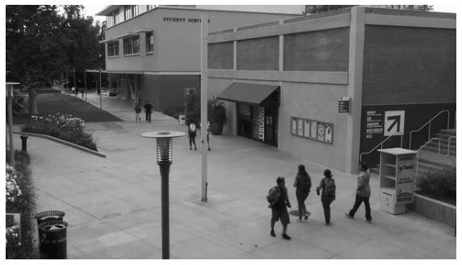

```
(338, 600)
```

```python
import numpy as np
import cv2
import matplotlib.pyplot as plt
%matplotlib inline

img = cv2.imread('./data_files/capimage_0.jpg', 0)

plt.figure(figsize = (10,8))
plt.imshow(img, 'gray')
plt.axis('off')
plt.show()

print(img.shape)
row = 338
col = 600
```

(b) Load the image into grayscale and reshape each picture as (row $\times$ col, 1) shape, then stack them to form matrix $A$ with a shape of (row $\times$ col, 20).

```python
for i in range(20):
    image = cv2.imread(f'./image_files/capimage_{i}.jpg')
    image = cv2.cvtColor(image, cv2.COLOR_BGR2GRAY)
    if i == 0:
        orig_shape = image.shape
        arr = image[:,:]
        flat_arr = arr.reshape(orig_shape[0] * orig_shape[1], 1)
        flat_vector = flat_arr
    else:
        arr = image[:,:]
        flat = arr.reshape(orig_shape[0] * orig_shape[1], 1)
        flat_vector = np.hstack([flat_vector, flat])

A = flat_vector
```

(c) Compute SVD of matrix $A$ and plot the sigular values.

```python
import numpy as np
import cv2
import matplotlib.pyplot as plt

[U, S, VT] = np.linalg.svd(A, full_matrices = False)

U = np.asmatrix(U)
S = np.asmatrix(np.diag(S))
VT = np.asmatrix(VT)

print(U.shape, S.shape, VT.shape, '\n')
```

```
(202800, 20) (20, 20) (20, 20)
```

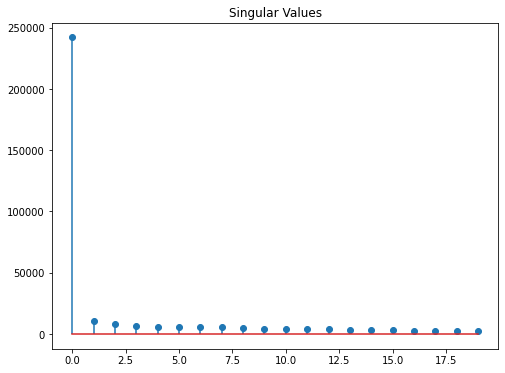

```python
sig_val = np.diag(S)

plt.figure(figsize = (8,6))
plt.stem(sig_val)
plt.title('Singular Values')
plt.show()
```

(d) Apply low rank approximation to matrix $A$ with $k=1$, and then plot $\hat A[:,0]$ with a reshape of (row, col).

$$\hat A = U_k \Sigma_k V_k^T = \sum_{i=1}^{k}\sigma_i u_i v_i^T \qquad (k = 1)$$

[figure not shown]

```python
A_hat = U[:,0]*S[0,0]*VT[0,:]

plt.figure(figsize = (10, 8))

plt.imshow(A_hat[:, 0].reshape(row, col), 'gray')
plt.axis('off')
plt.show()
```

(e) Explain why we have the above result.

Decompose $A$ into $U, S, V$ by applying SVD method. After that, reconstruct $\hat{A}$ by low rank approximation for $rank = 1$. Because the background is almost the same for each frame, the information will be contained in $\hat A[:,0]$.

# Problem 13

I have demonstrated the PCA algorithm with a spring and mass system in class.

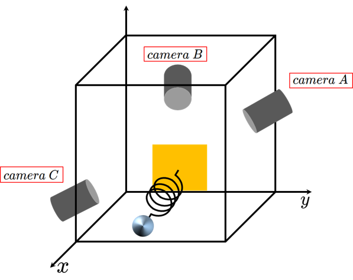

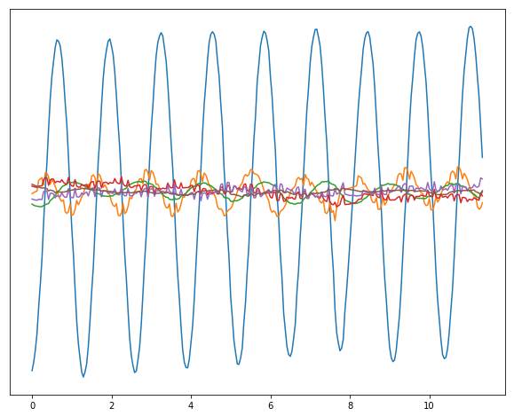

[8pt] We want to make the same results using SVD at this time. Use the same data set used in class.

Download [files](https://www.dropbox.com/s/9skaad3vei8be2l/pca_spring.pkl?dl=1)

```python
import numpy as np
import matplotlib.pyplot as plt
%matplotlib inline

data_sp = np.load(open('./data_files/pca_spring.npy', 'rb'))

X = data_sp.T
X = np.asmatrix(X)

print(X.shape)
```

```
(273, 6)
```

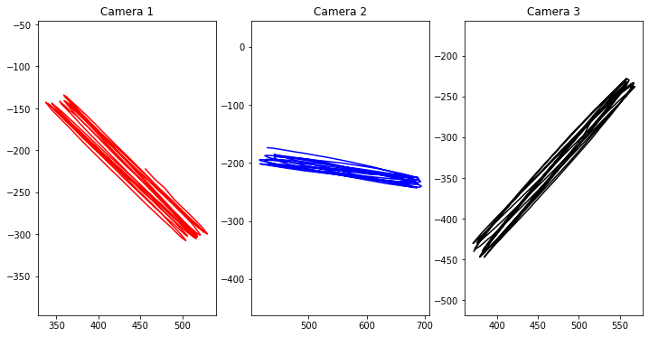

```python
plt.figure(figsize = (12, 6))

plt.subplot(1,3,1)
plt.plot(X[:, 0], -X[:, 1], 'r')
plt.axis('equal')
plt.title('Camera 1')

plt.subplot(1,3,2)
plt.plot(X[:, 2], -X[:, 3], 'b')
plt.axis('equal')
plt.title('Camera 2')

plt.subplot(1,3,3)
plt.plot(X[:, 4], -X[:, 5], 'k')
plt.axis('equal')
plt.title('Camera 3')

plt.show()
```

```python
X = X - np.mean(X, axis = 0)

## write your code here
#
```

```python
## write your code here
#
```

```python
## write your code here
#
```

# Solution 13

I have demonstrated the PCA algorithm with a spring and mass system in class.

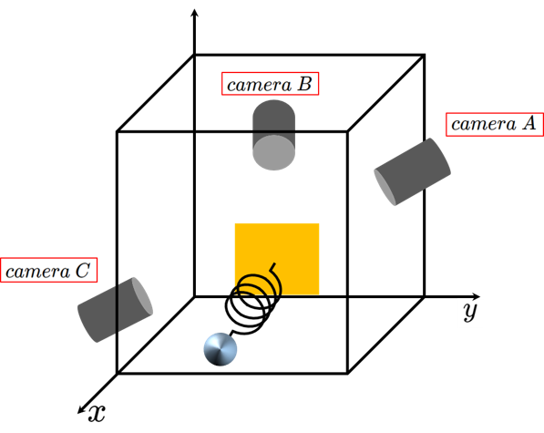

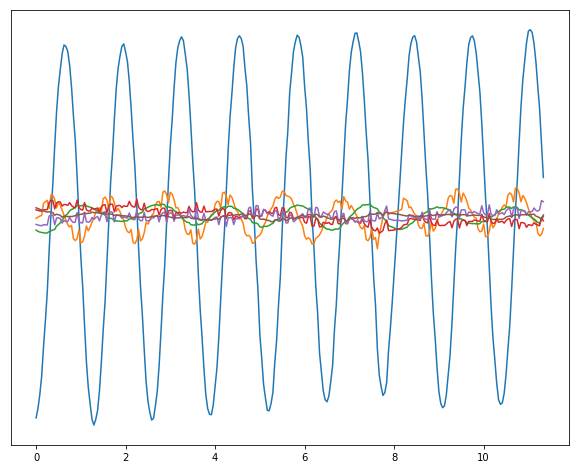

[8pt] We want to make the same results using SVD at this time. Use the same data set used in class.

Download [files](https://www.dropbox.com/s/9skaad3vei8be2l/pca_spring.pkl?dl=1)

```python
from six.moves import cPickle
import numpy as np
import matplotlib.pyplot as plt

data_sp = cPickle.load(open('./data_files/pca_spring.pkl', 'rb'))

X = data_sp.T
X = np.asmatrix(X)

print(X.shape)
```

```
(273, 6)
```

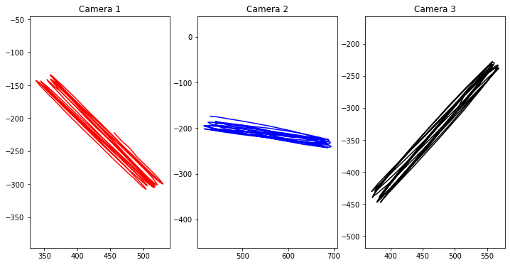

```python
plt.figure(figsize = (12, 6))

plt.subplot(1,3,1)
plt.plot(X[:, 0], -X[:, 1], 'r')
plt.axis('equal')
plt.title('Camera 1')

plt.subplot(1,3,2)
plt.plot(X[:, 2], -X[:, 3], 'b')
plt.axis('equal')
plt.title('Camera 2')

plt.subplot(1,3,3)
plt.plot(X[:, 4], -X[:, 5], 'k')
plt.axis('equal')
plt.title('Camera 3')

plt.show()
```

```python
X = X - np.mean(X, axis = 0)

[U1, S1, VT1] = np.linalg.svd(X, full_matrices = True)

U1 = np.asmatrix(U1)
S1 = np.asmatrix(np.diag(S1))
VT1 = np.asmatrix(VT1)

print(U1.shape, S1.shape, VT1.shape, '\n')
print(U1, '\n')
print(S1, '\n')
print(VT1)
```

```
(273, 273) (6, 6) (6, 6)

[[-9.22862699e-02  8.72763441e-03  1.06812579e-01 ...  4.81409767e-02
   3.60856816e-02  4.90326897e-03]
 [-8.81116190e-02  4.11756041e-03  1.16318837e-01 ...  1.13877871e-01
   1.08989300e-01  1.03163280e-01]
 [-8.16755367e-02 -2.78009420e-04  1.22411476e-01 ... -6.81743555e-02
  -3.32162582e-03 -5.63855843e-03]
 ...
 [ 4.90575646e-02  7.88824434e-02  5.65194689e-02 ...  9.76161188e-01
  -2.40959824e-02 -1.71032284e-02]
 [ 3.32089715e-02  7.24710262e-02  2.76949242e-02 ... -2.52992885e-02
   9.56163469e-01 -2.99707764e-02]
 [ 1.76972809e-02  4.94238245e-02  6.54457776e-04 ... -1.93247330e-02
  -3.24611861e-02  9.65194989e-01]]

[[2586.90935886    0.            0.            0.            0.
     0.        ]
 [   0.          296.28904012    0.            0.            0.
     0.        ]
 [   0.            0.          154.17117295    0.            0.
     0.        ]
 [   0.            0.            0.          149.30221817    0.
     0.        ]
 [   0.            0.            0.            0.           93.21752893
     0.        ]
 [   0.            0.            0.            0.            0.
    44.95090112]]

[[ 0.36881064  0.35632379  0.58419477  0.08652315  0.4159798  -0.46389987]
 [-0.62298194 -0.57286174  0.22610057  0.02671281  0.29900638 -0.37746931]
 [ 0.12571821 -0.132303    0.20325551 -0.75692234 -0.49374948 -0.32963322]
 [-0.42647348  0.59881765 -0.47751523 -0.14177391  0.05637591 -0.45633202]
 [ 0.52121775 -0.40143215 -0.58153918 -0.06010869  0.32442517 -0.34660023]
 [-0.0807439   0.08734045  0.00857804 -0.62861422  0.62075559  0.45308403]]
```

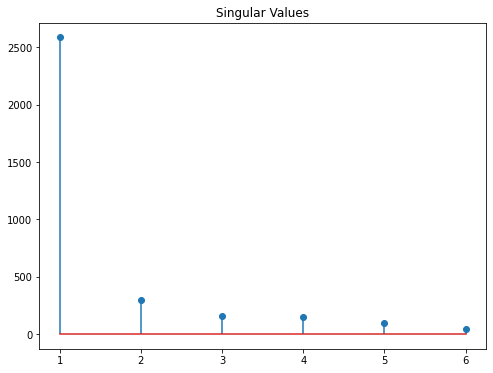

```python
sig_val = np.diag(S1)

plt.figure(figsize = (8,6))
plt.stem(range(1,7), sig_val)
plt.xticks(range(1,7))
plt.title('Singular Values')
plt.show()
```

[figure not shown]

```python
plt.figure(figsize = (10, 8))
plt.plot(X*S1)
plt.yticks([])
plt.show()
```

```python
k = 1

low_U1 = U1[:, :k]
low_S1 = S1[:k, :k]
low_VT1 = VT1[:k, :k]

X_approx = low_U1*low_S1*low_VT1

# print(low_U1.shape, low_S1.shape, low_VT1.shape, '\n')
# print('A:\n', X ,'\n')
# print('A_approx:\n', X_approx, '\n')
# print('low_U:\n', low_U1, '\n')
# print('low_VT:\n', low_VT1)
```

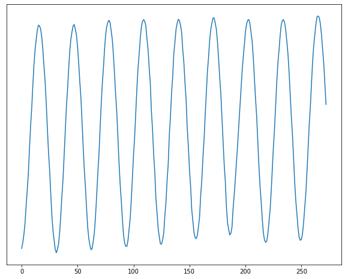

```python
plt.figure(figsize = (10, 8))
plt.plot(X_approx)
plt.yticks([])
plt.show()
```

```python
k = 1

low_U1 = U1[:, 0]
low_S1 = S1[0, 0]
low_VT1 = VT1[0,0]

# X_approx = low_U1*low_S1*low_VT1

X_approx = low_U1

# print(low_U1.shape, low_S1.shape, low_VT1.shape, '\n')
# print('A:\n', X ,'\n')
# print('A_approx:\n', X_approx, '\n')
# print('low_U:\n', low_U1, '\n')
# print('low_VT:\n', low_VT1)
```

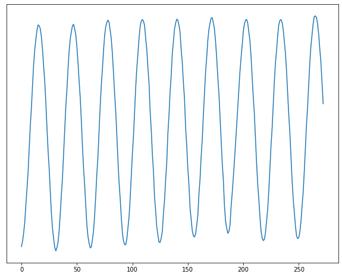

```python
plt.figure(figsize = (10, 8))
plt.plot(X_approx)
plt.yticks([])
plt.show()
```